# experiment1 data raw

Joseph Outa

2025-05-11

```r
library(codebook)
```

```r
knit_by_pkgdown <- !is.null(knitr::opts_chunk$get("fig.retina"))
knitr::opts_chunk$set(
  warning = TRUE, # show warnings during codebook generation
  message = TRUE, # show messages during codebook generation
  error = TRUE, # do not interrupt codebook generation in case of errors,
                # TRUE is usually better for debugging
  echo = TRUE  # show R code
)

library(pacman)
pacman::p_load(tidyverse, labelled, here, codebook)
ggplot2::theme_set(ggplot2::theme_bw())
```

# 1 Read data

```r
codebook::codebook(d)
```

### 1.0.1 Metadata

#### 1.0.1.1 Description

**Dataset name**: Raw data for Study 1

**Metadata for search engines**

| name | value |
| --- | --- |
| keywords | subject_id, trial_type, trial_index, plugin_version, time_elapsed, trial_id, rt, stimulus, response, view_history, 0, 1, 2, 3, 4, 5, 6, 7, 8, 9, 10, 11, 12, 13, 14, question_order, 15, init_locations,… |

## 1.1 Variables

### 1.1.1 subject_id

#### 1.1.1.1 Distribution

```
## 102  unique, categorical values, so not shown.
```

0 missing values.

#### 1.1.1.2 Summary statistics

[output not shown]

### 1.1.2 trial_type

Type of jspsych trial. Trials in jspsych represent checkpoints in the experiment, such as the instructions page, the survey page etc

#### 1.1.2.1 Distribution

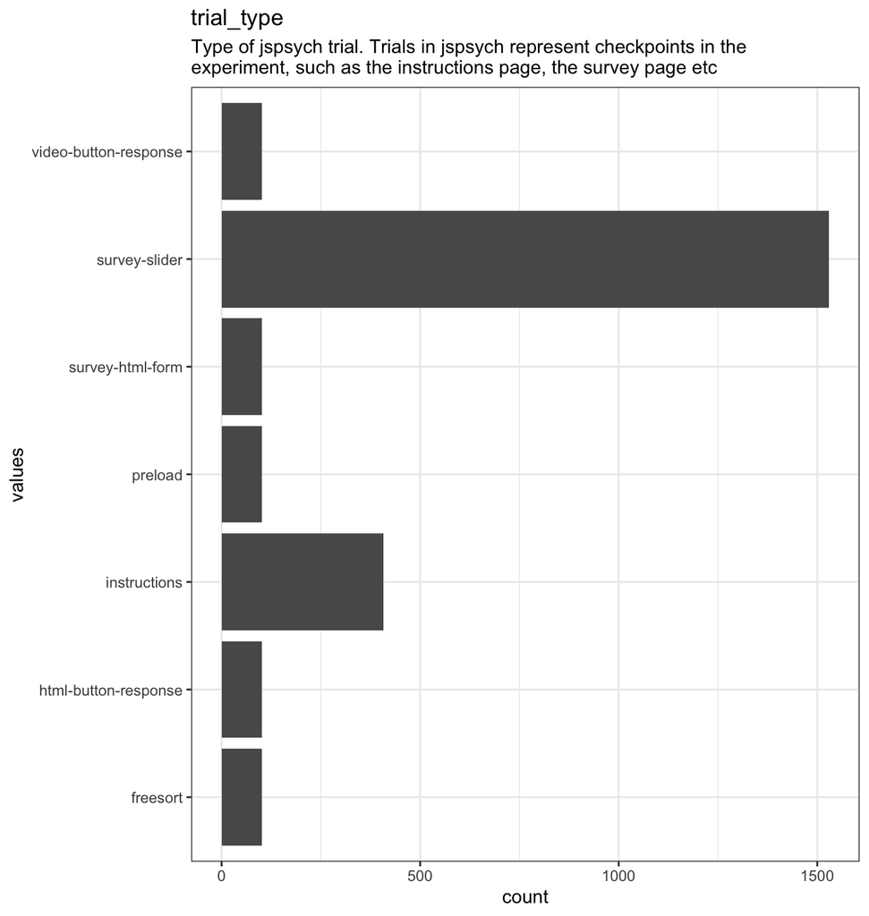

Figure 1.1: Distribution of values for trial_type

0 missing values.

#### 1.1.2.2 Summary statistics

| name | label | data_type | n_missing | complete_rate | n_unique | empty | min | max | whitespace |
| --- | --- | --- | --- | --- | --- | --- | --- | --- | --- |
| trial_type | Type of jspsych trial. Trials in jspsych represent checkpoints in the experiment, such as the instructions page, the survey page etc | character | 0 | 1 | 7 | 0 | 7 | 21 | 0 |

### 1.1.3 trial_index

Each subject did about 23 trials (Note: trial in the jspsych sense, since this raw data.

#### 1.1.3.1 Distribution

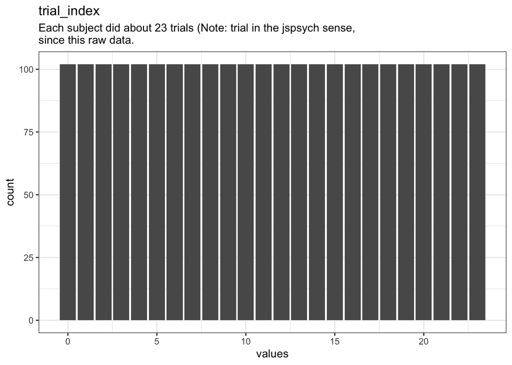

Figure 1.2: Distribution of values for trial_index

0 missing values.

#### 1.1.3.2 Summary statistics

| name | label | data_type | n_missing | complete_rate | min | median | max | mean | sd | hist |
| --- | --- | --- | --- | --- | --- | --- | --- | --- | --- | --- |
| trial_index | Each subject did about 23 trials (Note: trial in the jspsych sense, since this raw data. | numeric | 0 | 1 | 0 | 12 | 23 | 11.5 | 6.923601 | ▇▇▆▇▇ |

### 1.1.4 plugin_version

Plugin version that the subject had for the jspsych trials

#### 1.1.4.1 Distribution

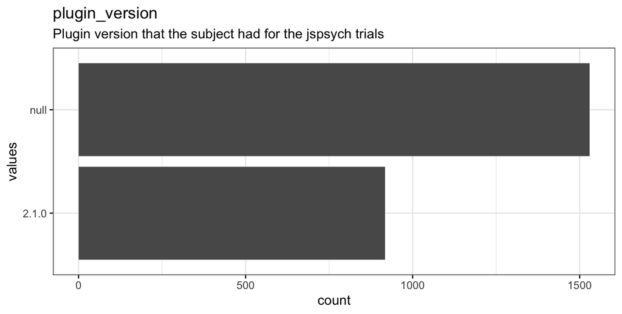

Figure 1.3: Distribution of values for plugin_version

0 missing values.

#### 1.1.4.2 Summary statistics

| name | label | data_type | n_missing | complete_rate | n_unique | empty | min | max | whitespace |
| --- | --- | --- | --- | --- | --- | --- | --- | --- | --- |
| plugin_version | Plugin version that the subject had for the jspsych trials | character | 0 | 1 | 2 | 0 | 4 | 5 | 0 |

### 1.1.5 time_elapsed

Time in milliseconds the subject spent on a given trial

#### 1.1.5.1 Distribution

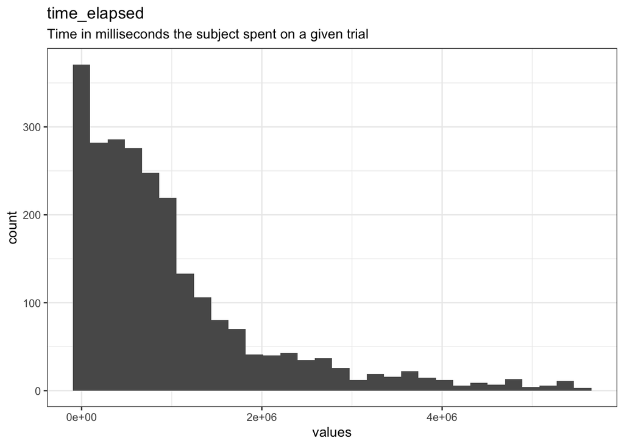

Figure 1.4: Distribution of values for time_elapsed

0 missing values.

#### 1.1.5.2 Summary statistics

| name | label | data_type | n_missing | complete_rate | min | median | max | mean | sd | hist |
| --- | --- | --- | --- | --- | --- | --- | --- | --- | --- | --- |
| time_elapsed | Time in milliseconds the subject spent on a given trial | numeric | 0 | 1 | 38 | 678281 | 5559470 | 986104.6 | 1056457 | ▇▂▁▁▁ |

### 1.1.6 trial_id

Researcher-assigned trial names. Trials highlighted were the consent, example_videos and demorgraphics_survey

#### 1.1.6.1 Distribution

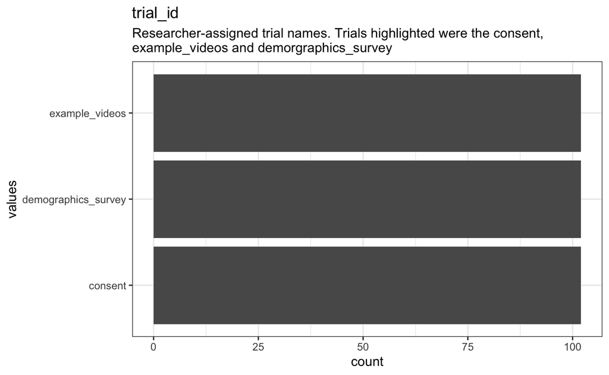

Figure 1.5: Distribution of values for trial_id

2142 missing values.

#### 1.1.6.2 Summary statistics

| name | label | data_type | n_missing | complete_rate | n_unique | empty | min | max | whitespace |
| --- | --- | --- | --- | --- | --- | --- | --- | --- | --- |
| trial_id | Researcher-assigned trial names. Trials highlighted were the consent, example_videos and demorgraphics_survey | character | 2142 | 0.125 | 3 | 0 | 7 | 19 | 0 |

### 1.1.7 rt

Time it takes in milliseconds from when the page loads to when subject clicks on continue button

#### 1.1.7.1 Distribution

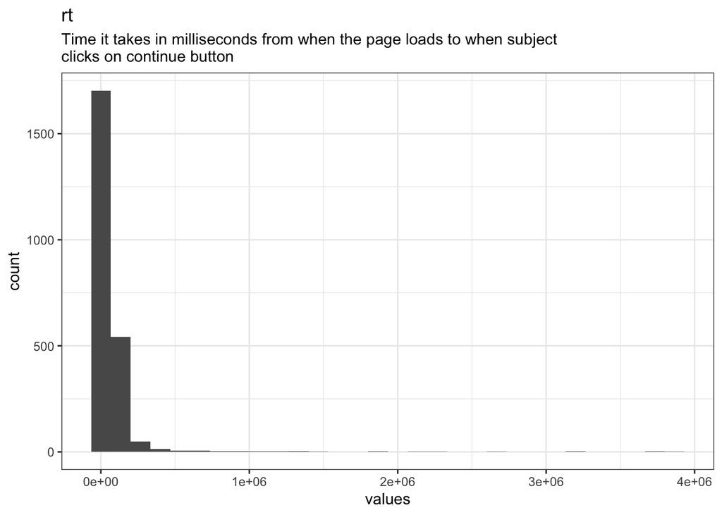

Figure 1.6: Distribution of values for rt

102 missing values.

#### 1.1.7.2 Summary statistics

| name | label | data_type | n_missing | complete_rate | min | median | max | mean | sd | hist |
| --- | --- | --- | --- | --- | --- | --- | --- | --- | --- | --- |
| rt | Time it takes in milliseconds from when the page loads to when subject clicks on continue button | numeric | 102 | 0.9583333 | 1092 | 47343 | 3865213 | 79596.48 | 217900.4 | ▇▁▁▁▁ |

### 1.1.8 stimulus

Html-formatted string describing the stimulus presented to participant on trials that had a stimulus

#### 1.1.8.1 Distribution

[figure not shown]

Figure 1.7: Distribution of values for stimulus

2244 missing values.

#### 1.1.8.2 Summary statistics

| name | label | data_type | n_missing | complete_rate | n_unique | empty | min | max | whitespace |
| --- | --- | --- | --- | --- | --- | --- | --- | --- | --- |
| stimulus | Html-formatted string describing the stimulus presented to participant on trials that had a stimulus | character | 2244 | 0.0833333 | 2 | 0 | 35 | 1959 | 0 |

### 1.1.9 response

#### 1.1.9.1 Distribution

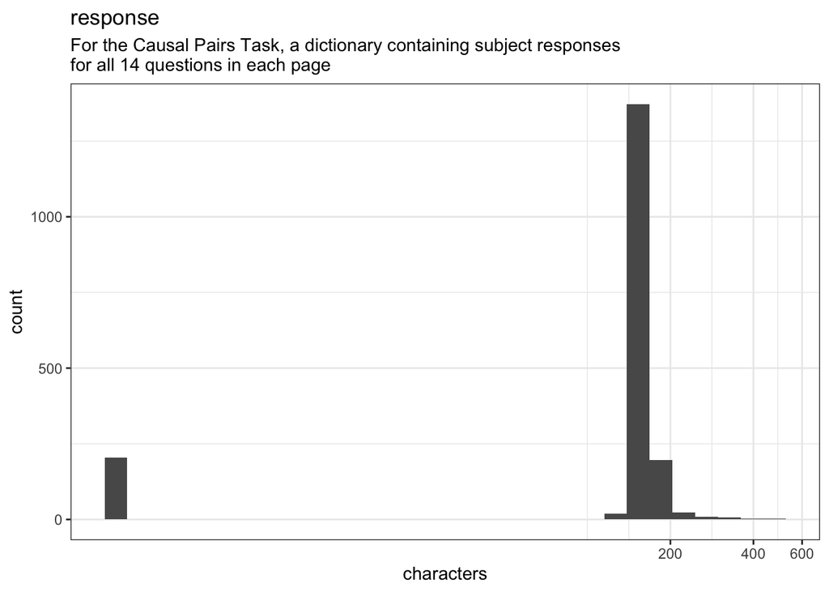

Figure 1.8: Distribution of values for response

612 missing values.

#### 1.1.9.2 Summary statistics

[output not shown]

### 1.1.10 view_history

A dictionary containing the index of the page and viewing time in milliseconds

#### 1.1.10.1 Distribution

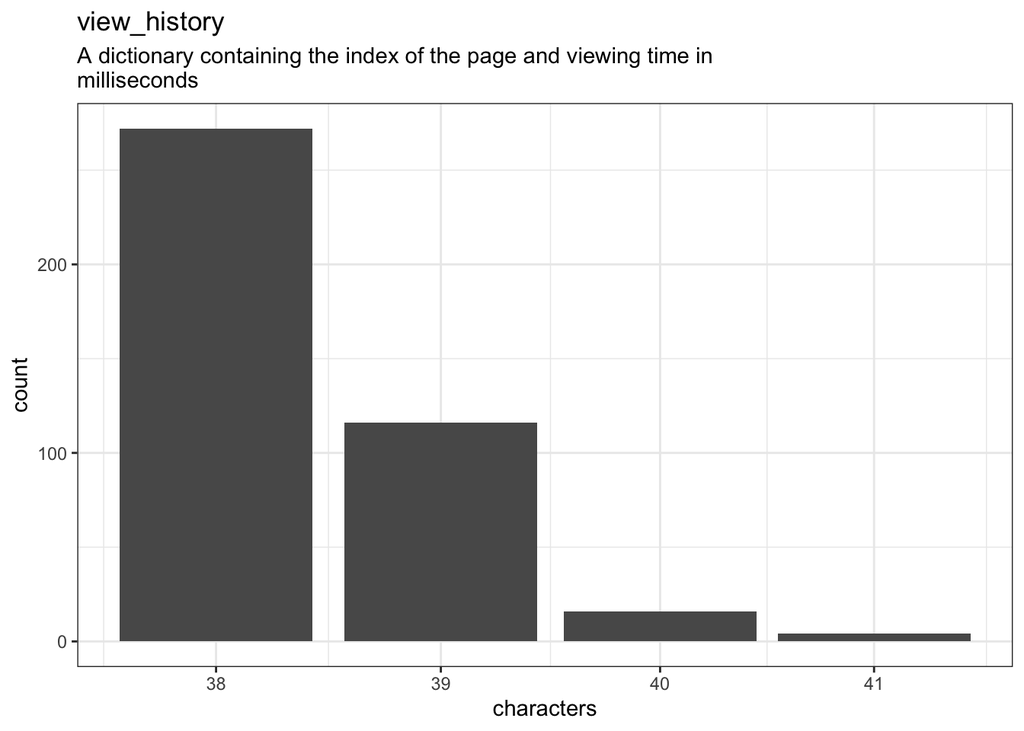

Figure 1.9: Distribution of values for view_history

2040 missing values.

#### 1.1.10.2 Summary statistics

| name | label | data_type | n_missing | complete_rate | n_unique | empty | min | max | whitespace |
| --- | --- | --- | --- | --- | --- | --- | --- | --- | --- |
| view_history | A dictionary containing the index of the page and viewing time in milliseconds | character | 2040 | 0.1666667 | 399 | 0 | 38 | 41 | 0 |

### 1.1.11 0

For the Sorting Task, a dictionary describing metadata about the first pair of items subjects saw

#### 1.1.11.1 Distribution

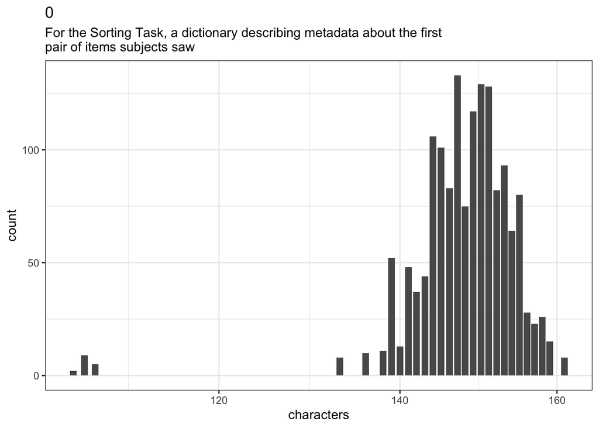

Figure 1.10: Distribution of values for 0

918 missing values.

#### 1.1.11.2 Summary statistics

| name | label | data_type | n_missing | complete_rate | n_unique | empty | min | max | whitespace |
| --- | --- | --- | --- | --- | --- | --- | --- | --- | --- |
| 0 | For the Sorting Task, a dictionary describing metadata about the first pair of items subjects saw | character | 918 | 0.625 | 228 | 0 | 106 | 161 | 0 |

### 1.1.12 1

For the Sorting Task, a dictionary describing metadata about the second pair of items subjects saw

#### 1.1.12.1 Distribution

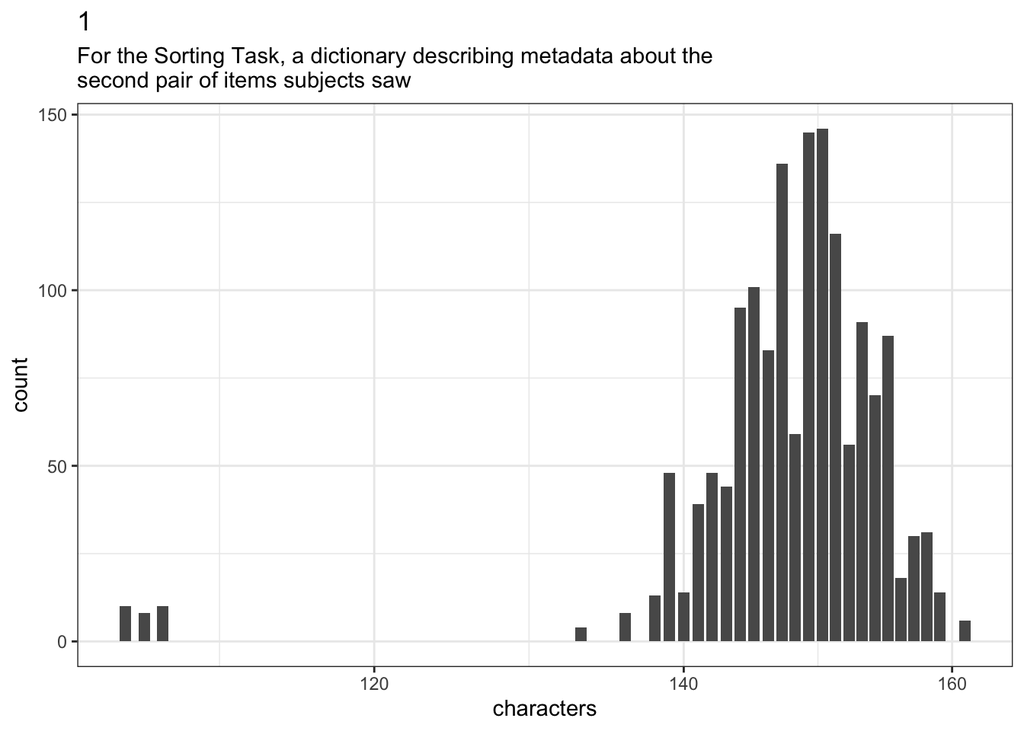

Figure 1.11: Distribution of values for 1

918 missing values.

#### 1.1.12.2 Summary statistics

| name | label | data_type | n_missing | complete_rate | n_unique | empty | min | max | whitespace |
| --- | --- | --- | --- | --- | --- | --- | --- | --- | --- |
| 1 | For the Sorting Task, a dictionary describing metadata about the second pair of items subjects saw | character | 918 | 0.625 | 228 | 0 | 106 | 161 | 0 |

### 1.1.13 2

For the Sorting Task, a dictionary describing metadata about the third pair of items subjects saw

#### 1.1.13.1 Distribution

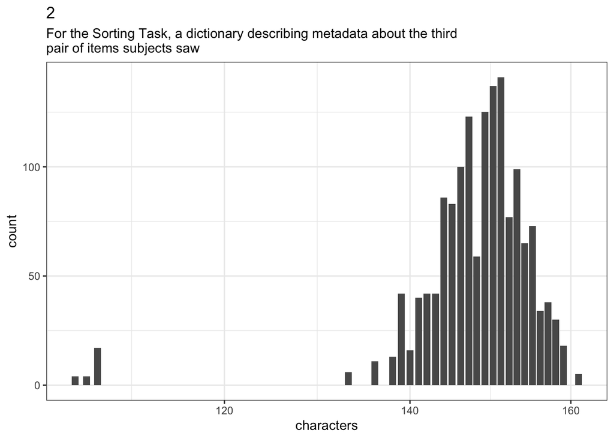

Figure 1.12: Distribution of values for 2

918 missing values.

#### 1.1.13.2 Summary statistics

| name | label | data_type | n_missing | complete_rate | n_unique | empty | min | max | whitespace |
| --- | --- | --- | --- | --- | --- | --- | --- | --- | --- |
| 2 | For the Sorting Task, a dictionary describing metadata about the third pair of items subjects saw | character | 918 | 0.625 | 228 | 0 | 106 | 161 | 0 |

### 1.1.14 3

For the Sorting Task, a dictionary describing metadata about the fourth pair of items subjects saw

#### 1.1.14.1 Distribution

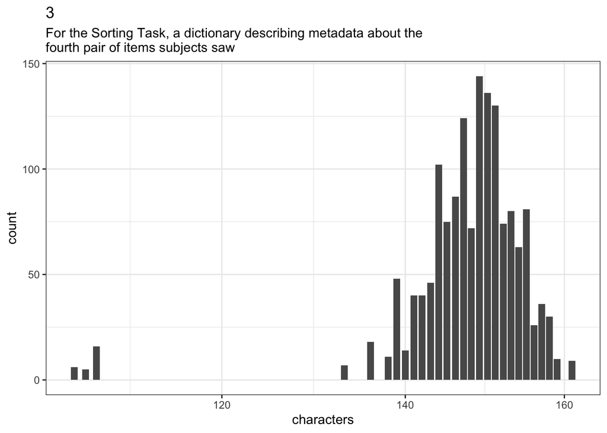

Figure 1.13: Distribution of values for 3

918 missing values.

#### 1.1.14.2 Summary statistics

| name | label | data_type | n_missing | complete_rate | n_unique | empty | min | max | whitespace |
| --- | --- | --- | --- | --- | --- | --- | --- | --- | --- |
| 3 | For the Sorting Task, a dictionary describing metadata about the fourth pair of items subjects saw | character | 918 | 0.625 | 228 | 0 | 106 | 161 | 0 |

### 1.1.15 4

For the Sorting Task, a dictionary describing metadata about the fifth pair of items subjects saw

#### 1.1.15.1 Distribution

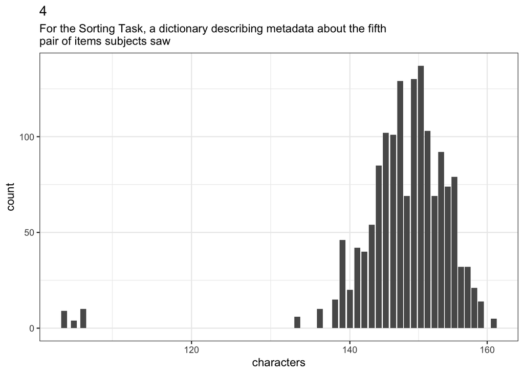

Figure 1.14: Distribution of values for 4

918 missing values.

#### 1.1.15.2 Summary statistics

| name | label | data_type | n_missing | complete_rate | n_unique | empty | min | max | whitespace |
| --- | --- | --- | --- | --- | --- | --- | --- | --- | --- |
| 4 | For the Sorting Task, a dictionary describing metadata about the fifth pair of items subjects saw | character | 918 | 0.625 | 228 | 0 | 106 | 161 | 0 |

### 1.1.16 5

For the Sorting Task, a dictionary describing metadata about the sixth pair of items subjects saw

#### 1.1.16.1 Distribution

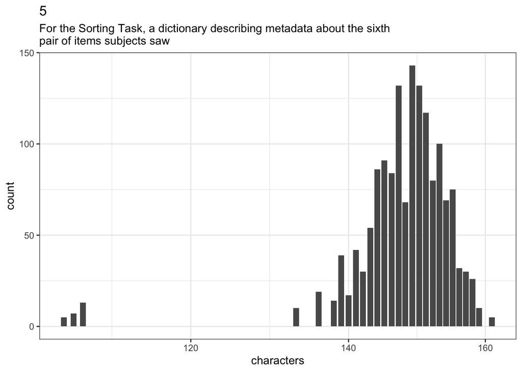

Figure 1.15: Distribution of values for 5

918 missing values.

#### 1.1.16.2 Summary statistics

| name | label | data_type | n_missing | complete_rate | n_unique | empty | min | max | whitespace |
| --- | --- | --- | --- | --- | --- | --- | --- | --- | --- |
| 5 | For the Sorting Task, a dictionary describing metadata about the sixth pair of items subjects saw | character | 918 | 0.625 | 228 | 0 | 106 | 161 | 0 |

### 1.1.17 6

For the Sorting Task, a dictionary describing metadata about the seventh pair of items subjects saw

#### 1.1.17.1 Distribution

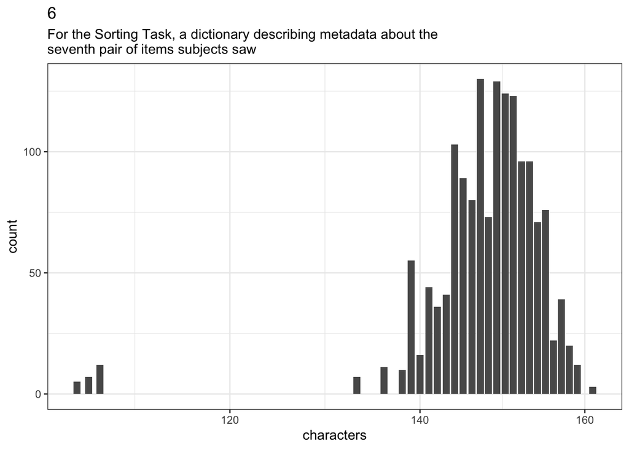

Figure 1.16: Distribution of values for 6

918 missing values.

#### 1.1.17.2 Summary statistics

| name | label | data_type | n_missing | complete_rate | n_unique | empty | min | max | whitespace |
| --- | --- | --- | --- | --- | --- | --- | --- | --- | --- |
| 6 | For the Sorting Task, a dictionary describing metadata about the seventh pair of items subjects saw | character | 918 | 0.625 | 228 | 0 | 106 | 161 | 0 |

### 1.1.18 7

For the Sorting Task, a dictionary describing metadata about the eighth pair of items subjects saw

#### 1.1.18.1 Distribution

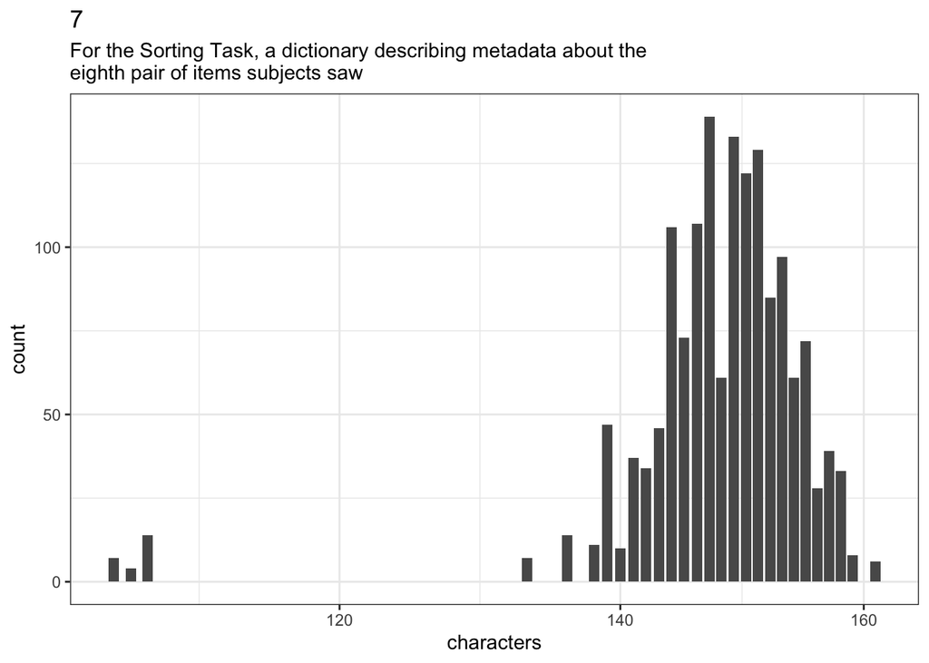

Figure 1.17: Distribution of values for 7

918 missing values.

#### 1.1.18.2 Summary statistics

| name | label | data_type | n_missing | complete_rate | n_unique | empty | min | max | whitespace |
| --- | --- | --- | --- | --- | --- | --- | --- | --- | --- |
| 7 | For the Sorting Task, a dictionary describing metadata about the eighth pair of items subjects saw | character | 918 | 0.625 | 228 | 0 | 106 | 161 | 0 |

### 1.1.19 8

#### 1.1.19.1 Distribution

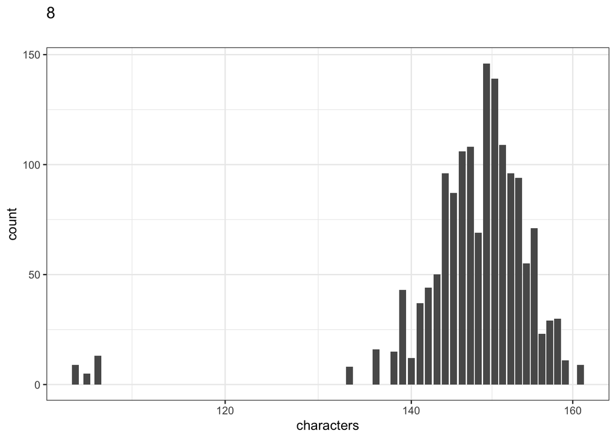

Figure 1.18: Distribution of values for 8

918 missing values.

#### 1.1.19.2 Summary statistics

| name | data_type | n_missing | complete_rate | n_unique | empty | min | max | whitespace | label |
| --- | --- | --- | --- | --- | --- | --- | --- | --- | --- |
| 8 | character | 918 | 0.625 | 228 | 0 | 106 | 161 | 0 | NA |

### 1.1.20 9

For the Sorting Task, a dictionary describing metadata about the ninth pair of items subjects saw

#### 1.1.20.1 Distribution

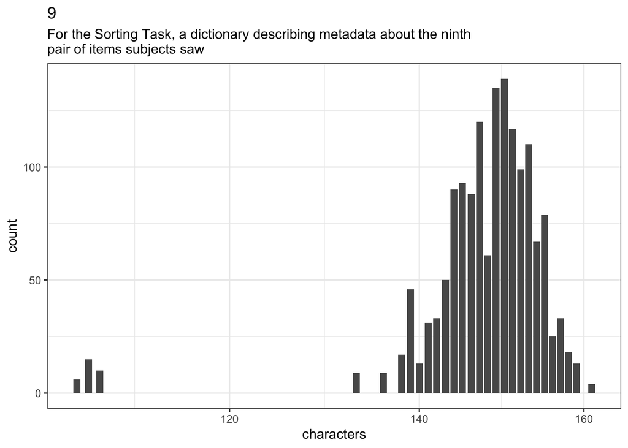

Figure 1.19: Distribution of values for 9

918 missing values.

#### 1.1.20.2 Summary statistics

| name | label | data_type | n_missing | complete_rate | n_unique | empty | min | max | whitespace |
| --- | --- | --- | --- | --- | --- | --- | --- | --- | --- |
| 9 | For the Sorting Task, a dictionary describing metadata about the ninth pair of items subjects saw | character | 918 | 0.625 | 225 | 0 | 106 | 161 | 0 |

### 1.1.21 10

For the Sorting Task, a dictionary describing metadata about the tenth pair of items subjects saw

#### 1.1.21.1 Distribution

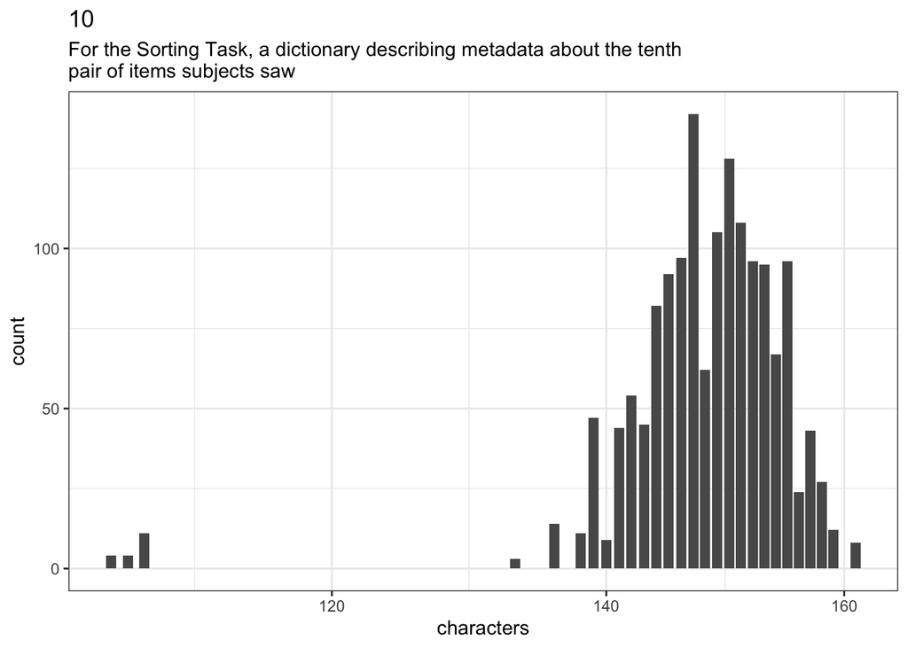

Figure 1.20: Distribution of values for 10

918 missing values.

#### 1.1.21.2 Summary statistics

| name | label | data_type | n_missing | complete_rate | n_unique | empty | min | max | whitespace |
| --- | --- | --- | --- | --- | --- | --- | --- | --- | --- |
| 10 | For the Sorting Task, a dictionary describing metadata about the tenth pair of items subjects saw | character | 918 | 0.625 | 228 | 0 | 106 | 161 | 0 |

### 1.1.22 11

For the Sorting Task, a dictionary describing metadata about the eleventh pair of items subjects saw

#### 1.1.22.1 Distribution

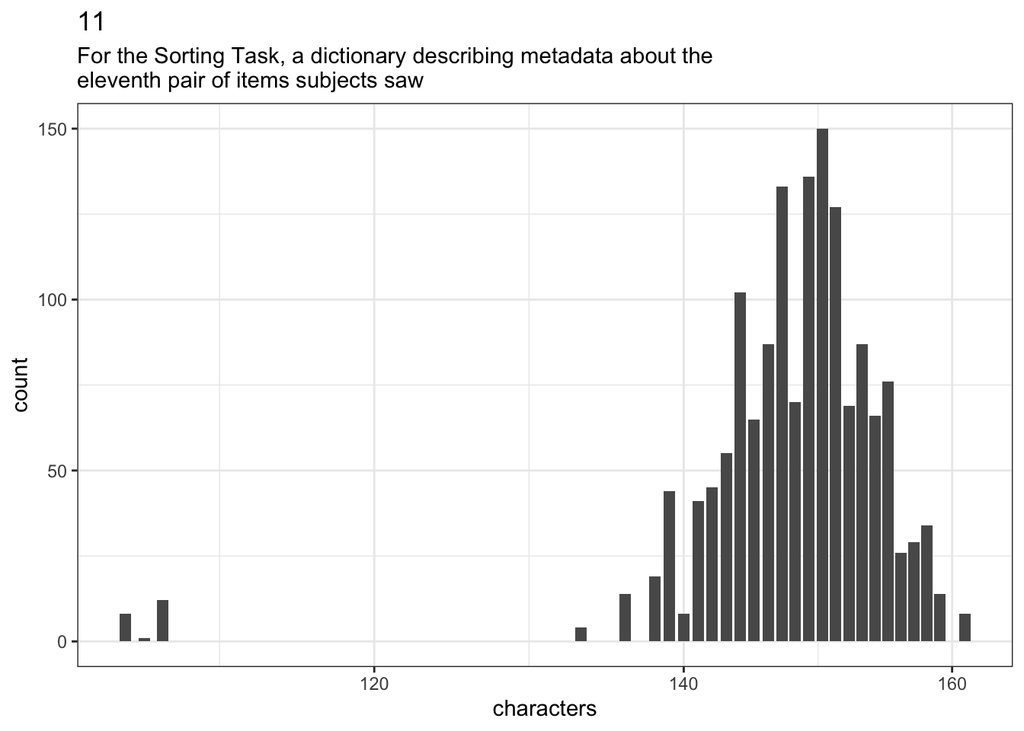

Figure 1.21: Distribution of values for 11

918 missing values.

#### 1.1.22.2 Summary statistics

| name | label | data_type | n_missing | complete_rate | n_unique | empty | min | max | whitespace |
| --- | --- | --- | --- | --- | --- | --- | --- | --- | --- |
| 11 | For the Sorting Task, a dictionary describing metadata about the eleventh pair of items subjects saw | character | 918 | 0.625 | 228 | 0 | 106 | 161 | 0 |

### 1.1.23 12

For the Sorting Task, a dictionary describing metadata about the twelfth pair of items subjects saw

#### 1.1.23.1 Distribution

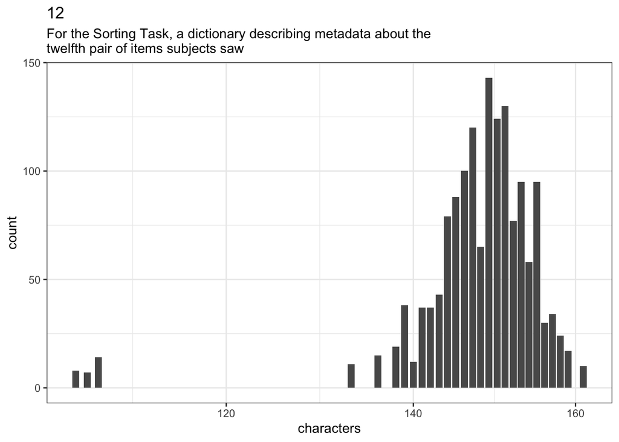

Figure 1.22: Distribution of values for 12

918 missing values.

#### 1.1.23.2 Summary statistics

| name | label | data_type | n_missing | complete_rate | n_unique | empty | min | max | whitespace |
| --- | --- | --- | --- | --- | --- | --- | --- | --- | --- |
| 12 | For the Sorting Task, a dictionary describing metadata about the twelfth pair of items subjects saw | character | 918 | 0.625 | 226 | 0 | 106 | 161 | 0 |

### 1.1.24 13

For the Sorting Task, a dictionary describing metadata about the thirtheenth pair of items subjects saw

#### 1.1.24.1 Distribution

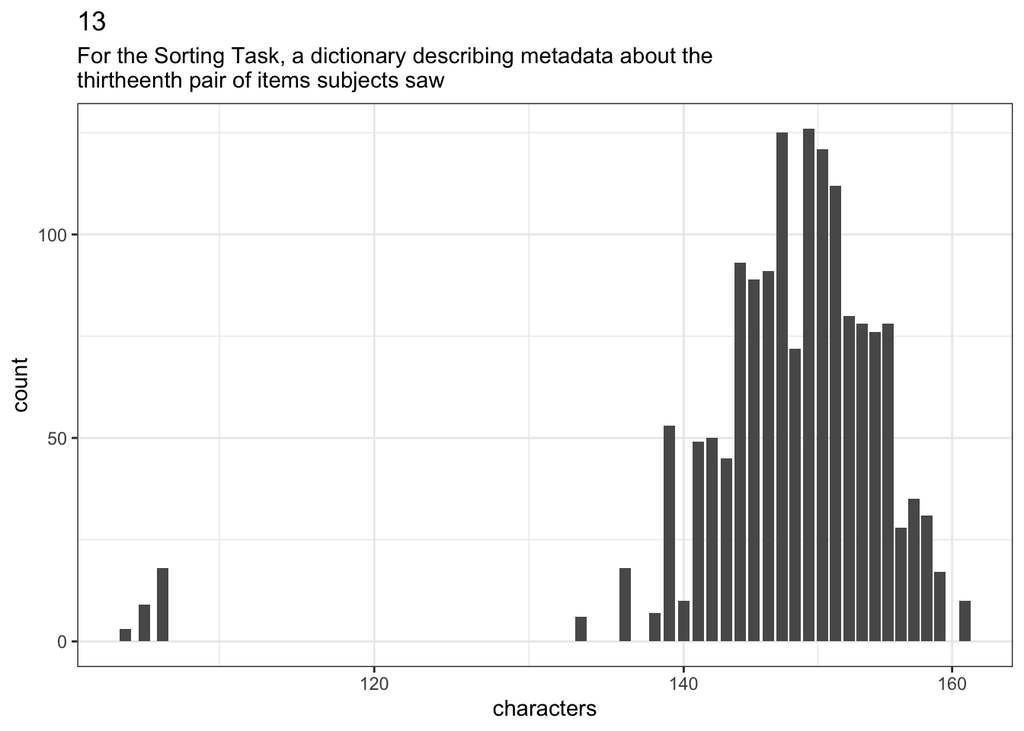

Figure 1.23: Distribution of values for 13

918 missing values.

#### 1.1.24.2 Summary statistics

| name | label | data_type | n_missing | complete_rate | n_unique | empty | min | max | whitespace |
| --- | --- | --- | --- | --- | --- | --- | --- | --- | --- |
| 13 | For the Sorting Task, a dictionary describing metadata about the thirtheenth pair of items subjects saw | character | 918 | 0.625 | 228 | 0 | 106 | 161 | 0 |

### 1.1.25 14

For the Sorting Task, a dictionary describing metadata about the fourtheenth pair of items subjects saw

#### 1.1.25.1 Distribution

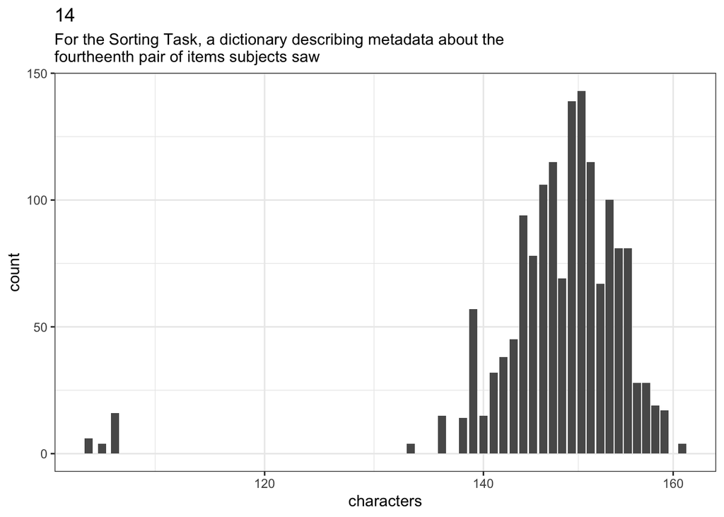

Figure 1.24: Distribution of values for 14

918 missing values.

#### 1.1.25.2 Summary statistics

| name | label | data_type | n_missing | complete_rate | n_unique | empty | min | max | whitespace |
| --- | --- | --- | --- | --- | --- | --- | --- | --- | --- |
| 14 | For the Sorting Task, a dictionary describing metadata about the fourtheenth pair of items subjects saw | character | 918 | 0.625 | 228 | 0 | 106 | 161 | 0 |

### 1.1.26 question_order

The order of questions seen by subjects

#### 1.1.26.1 Distribution

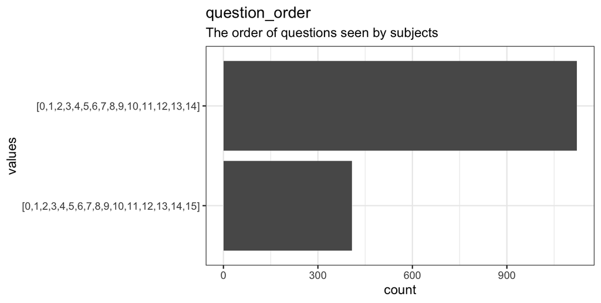

Figure 1.25: Distribution of values for question_order

918 missing values.

#### 1.1.26.2 Summary statistics

| name | label | data_type | n_missing | complete_rate | n_unique | empty | min | max | whitespace |
| --- | --- | --- | --- | --- | --- | --- | --- | --- | --- |
| question_order | The order of questions seen by subjects | character | 918 | 0.625 | 2 | 0 | 36 | 39 | 0 |

### 1.1.27 15

#### 1.1.27.1 Distribution

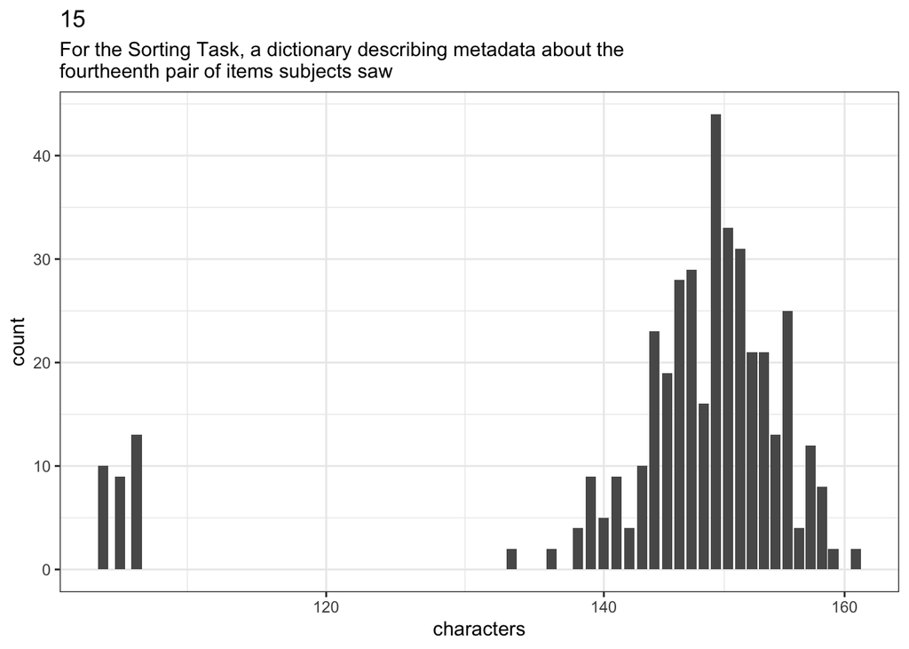

Figure 1.26: Distribution of values for 15

2040 missing values.

#### 1.1.27.2 Summary statistics

[output not shown]

### 1.1.28 init_locations

For the Sorting Task, a dictionary describing initial x and y locations of each item and the item name

#### 1.1.28.1 Distribution

[output not shown]

```
## No non-missing values to show.
```

2448 missing values.

#### 1.1.28.2 Summary statistics

| name | label | data_type | n_missing | complete_rate | count |
| --- | --- | --- | --- | --- | --- |
| init_locations | For the Sorting Task, a dictionary describing initial x and y locations of each item and the item name | logical | 2448 | 0 | : |

### 1.1.29 moves

For the Sorting Task, a dictionary describing where x and y locations of where items were moved to

#### 1.1.29.1 Distribution

[output not shown]

```
## No non-missing values to show.
```

2448 missing values.

#### 1.1.29.2 Summary statistics

| name | label | data_type | n_missing | complete_rate | count |
| --- | --- | --- | --- | --- | --- |
| moves | For the Sorting Task, a dictionary describing where x and y locations of where items were moved to | logical | 2448 | 0 | : |

### 1.1.30 final_locations

For the Sorting Task, a dictionary describing final x and y locations of each item and the item name

#### 1.1.30.1 Distribution

[output not shown]

```
## No non-missing values to show.
```

2448 missing values.

#### 1.1.30.2 Summary statistics

| name | label | data_type | n_missing | complete_rate | count |
| --- | --- | --- | --- | --- | --- |
| final_locations | For the Sorting Task, a dictionary describing final x and y locations of each item and the item name | logical | 2448 | 0 | : |

### 1.1.31 feedback

feedback provided by subjects

#### 1.1.31.1 Distribution

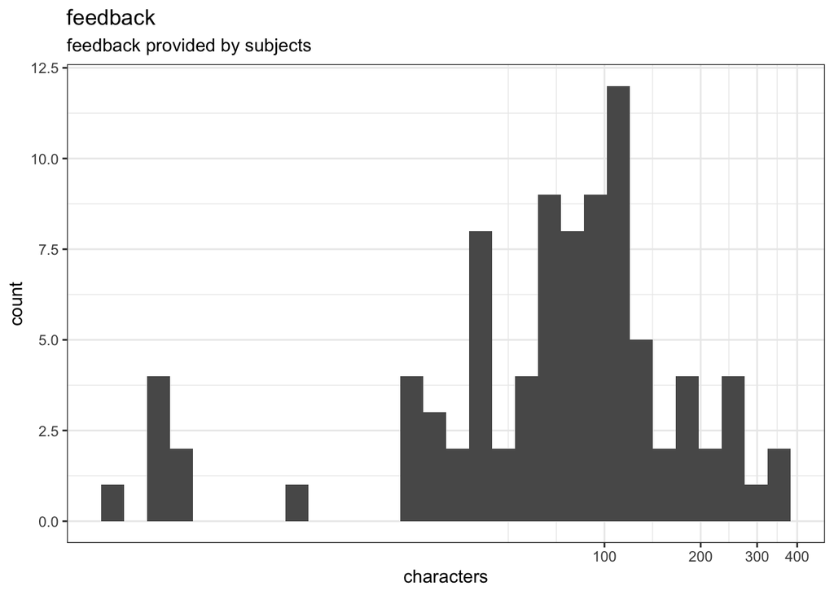

Figure 1.27: Distribution of values for feedback

2359 missing values.

#### 1.1.31.2 Summary statistics

| name | label | data_type | n_missing | complete_rate | n_unique | empty | min | max | whitespace |
| --- | --- | --- | --- | --- | --- | --- | --- | --- | --- |
| feedback | feedback provided by subjects | character | 2359 | 0.0363562 | 87 | 0 | 2 | 351 | 0 |

### 1.1.32 age

#### 1.1.32.1 Distribution

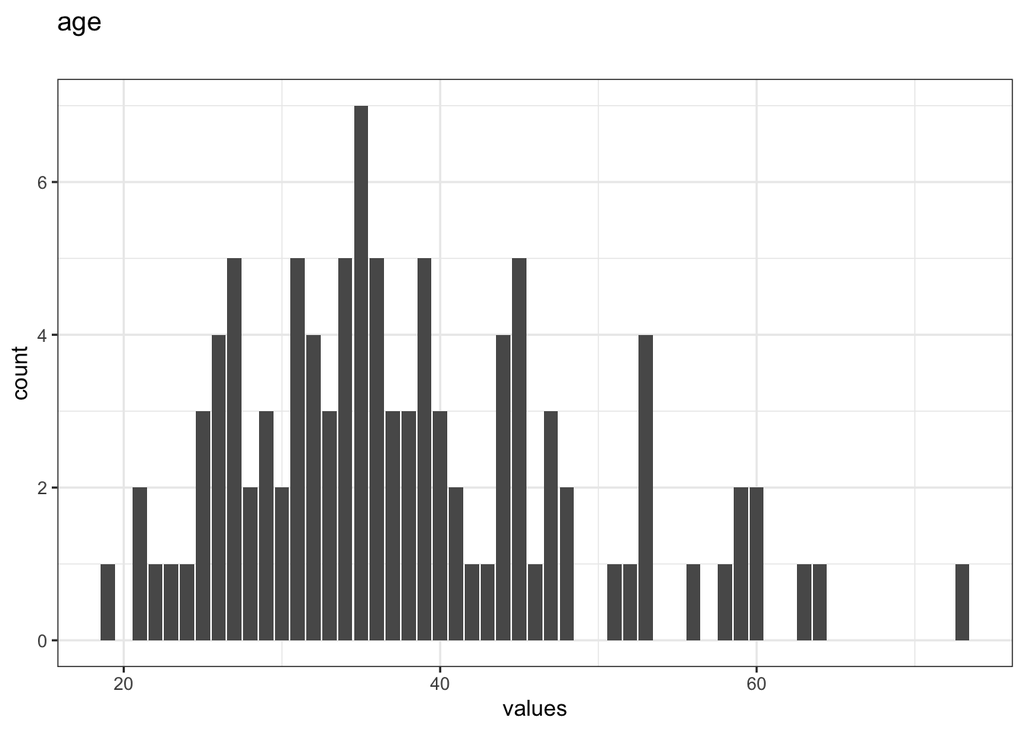

Figure 1.28: Distribution of values for age

2346 missing values.

#### 1.1.32.2 Summary statistics

| name | data_type | n_missing | complete_rate | min | median | max | mean | sd | hist | label |
| --- | --- | --- | --- | --- | --- | --- | --- | --- | --- | --- |
| age | numeric | 2346 | 0.0416667 | 19 | 36 | 73 | 38.05882 | 10.82793 | ▅▇▃▂▁ | NA |

### 1.1.33 ethnicity

#### 1.1.33.1 Distribution

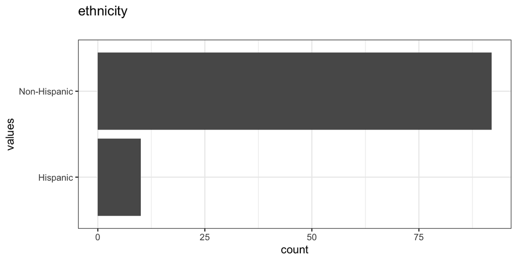

Figure 1.29: Distribution of values for ethnicity

2346 missing values.

#### 1.1.33.2 Summary statistics

| name | data_type | n_missing | complete_rate | n_unique | empty | min | max | whitespace | label |
| --- | --- | --- | --- | --- | --- | --- | --- | --- | --- |
| ethnicity | character | 2346 | 0.0416667 | 2 | 0 | 8 | 12 | 0 | NA |

### 1.1.34 gender

#### 1.1.34.1 Distribution

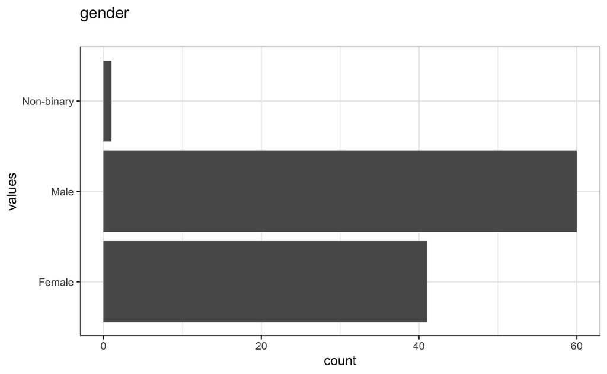

Figure 1.30: Distribution of values for gender

2346 missing values.

#### 1.1.34.2 Summary statistics

| name | data_type | n_missing | complete_rate | n_unique | empty | min | max | whitespace | label |
| --- | --- | --- | --- | --- | --- | --- | --- | --- | --- |
| gender | character | 2346 | 0.0416667 | 3 | 0 | 4 | 10 | 0 | NA |

### 1.1.35 race

#### 1.1.35.1 Distribution

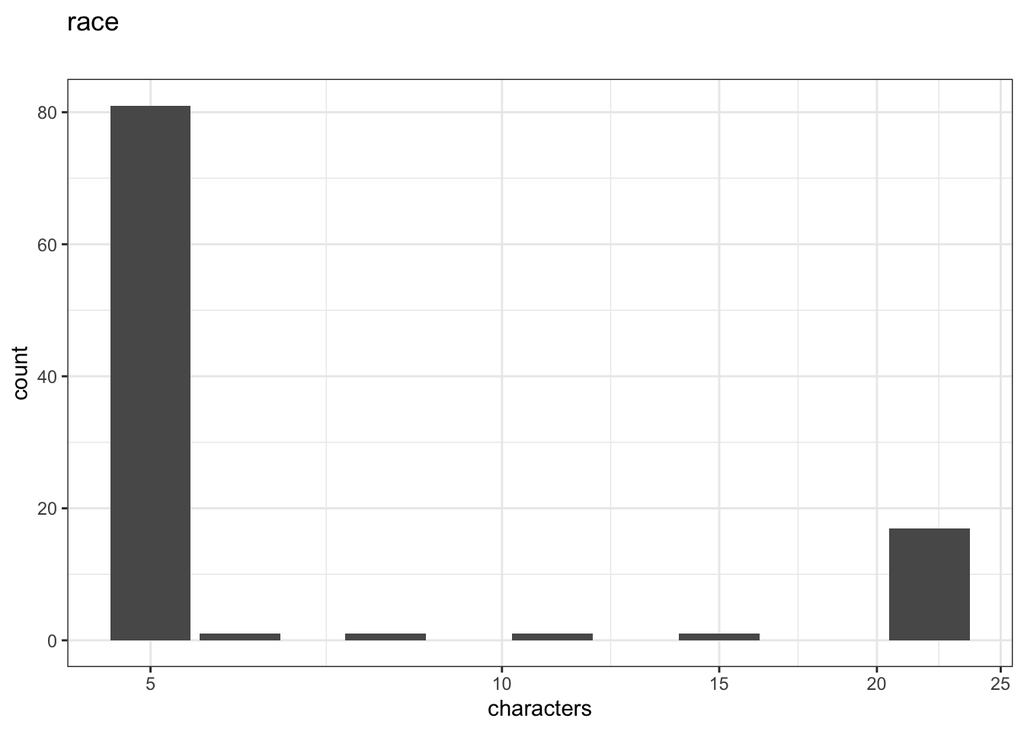

Figure 1.31: Distribution of values for race

2346 missing values.

#### 1.1.35.2 Summary statistics

| name | data_type | n_missing | complete_rate | n_unique | empty | min | max | whitespace | label |
| --- | --- | --- | --- | --- | --- | --- | --- | --- | --- |
| race | character | 2346 | 0.0416667 | 7 | 0 | 5 | 22 | 0 | NA |

## 1.2 Missingness report

| description | rt | response | 0 | 1 | 2 | 3 | 4 | 5 | 6 | 7 | 8 | 9 | 10 | 11 | 12 | 13 | 14 | question_order | view_history | 15 | trial_id | stimulus | age | ethnicity | gender | race | feedback | init_locations | moves | … |
| --- | --- | --- | --- | --- | --- | --- | --- | --- | --- | --- | --- | --- | --- | --- | --- | --- | --- | --- | --- | --- | --- | --- | --- | --- | --- | --- | --- | --- | --- | --- |
| Missing values per variable | 102 | 612 | 918 | 918 | 918 | 918 | 918 | 918 | 918 | 918 | 918 | 918 | 918 | 918 | 918 | 918 | 918 | 918 | 2040 | 2040 | 2142 | 2244 | 2346 | 2346 | 2346 | 2346 | 2359 | 2448 | 2448 | … |
| Missing values in 12 variables | 1 | 1 | 1 | 1 | 1 | 1 | 1 | 1 | 1 | 1 | 1 | 1 | 1 | 1 | 1 | 1 | 1 | 1 | 0 | 0 | 0 | 0 | 0 | 0 | 0 | 0 | 0 | 0 | 0 | … |
| Missing values in 11 variables | 1 | 1 | 1 | 1 | 1 | 1 | 1 | 1 | 1 | 1 | 1 | 1 | 1 | 1 | 1 | 1 | 1 | 1 | 0 | 1 | 0 | 0 | 0 | 0 | 0 | 0 | 0 | 0 | 0 | … |
| Missing values in 28 variables | 1 | 0 | 0 | 0 | 0 | 0 | 0 | 0 | 0 | 0 | 0 | 0 | 0 | 0 | 0 | 0 | 0 | 0 | 1 | 0 | 0 | 0 | 0 | 0 | 0 | 0 | 0 | 0 | 0 | … |
| Missing values in 26 variables | 1 | 1 | 0 | 0 | 0 | 0 | 0 | 0 | 0 | 0 | 0 | 0 | 0 | 0 | 0 | 0 | 0 | 0 | 0 | 0 | 1 | 1 | 0 | 0 | 0 | 0 | 0 | 0 | 0 | … |
| Missing values in 29 variables | 1 | 0 | 0 | 0 | 0 | 0 | 0 | 0 | 0 | 0 | 0 | 0 | 0 | 0 | 0 | 0 | 0 | 0 | 0 | 0 | 0 | 0 | 0 | 0 | 0 | 0 | 0 | 0 | 0 | … |
| Missing values in 30 variables | 0 | 0 | 0 | 0 | 0 | 0 | 0 | 0 | 0 | 0 | 0 | 0 | 0 | 0 | 0 | 0 | 0 | 0 | 0 | 0 | 0 | 0 | 0 | 0 | 0 | 0 | 0 | 0 | 0 | … |
| Missing values in 22 variables | 1 | 1 | 0 | 0 | 0 | 0 | 0 | 0 | 0 | 0 | 0 | 0 | 0 | 0 | 0 | 0 | 0 | 0 | 0 | 0 | 1 | 0 | 1 | 1 | 1 | 1 | 1 | 0 | 0 | … |
| 1 other, less frequent patterns | 1 | 1 | 0 | 0 | 0 | 0 | 0 | 0 | 0 | 0 | 0 | 0 | 0 | 0 | 0 | 0 | 0 | 0 | 0 | 0 | 1 | 0 | 1 | 1 | 1 | 1 | 0 | 0 | 0 | … |

## 1.3 Codebook table

[output not shown]

**JSON-LD metadata**